# Chi-squared test for association

The following code can be used for Categorical Variables to test if any two Categorical Variable are dependent

To preform our assessment we will be using the Chi-squared test for association from the scipy library

```python
import scipy
```

Next we will load the data that we will be using

```python
import pandas as pd
```

I created the Data set we will be using to demonstrate what association may look like in categorical data

```python
df = pd.read_csv('Example Car Data.csv')
```

```python
df.info()
```

```
<class 'pandas.core.frame.DataFrame'>
RangeIndex: 341 entries, 0 to 340
Data columns (total 5 columns):
 #   Column   Non-Null Count  Dtype
---  ------   --------------  -----
 0   Color    341 non-null    object
 1   Type     341 non-null    object
 2   Make     341 non-null    object
 3   Seats    341 non-null    int64
 4   Quality  341 non-null    object
dtypes: int64(1), object(4)
memory usage: 13.4+ KB
```

Looking at the data we can make the a few observations

```
1. Seats should be associated with the Type of Car i.e. a Sedan will most likely have 5 seats and a truck 2 seats
2. Color Type Make and quality should have no association
```

Let’s do some basic visualization before we preform our statistical test to view the frequency distribution of each categorical variable values.

```python
import matplotlib.pyplot as plt
```

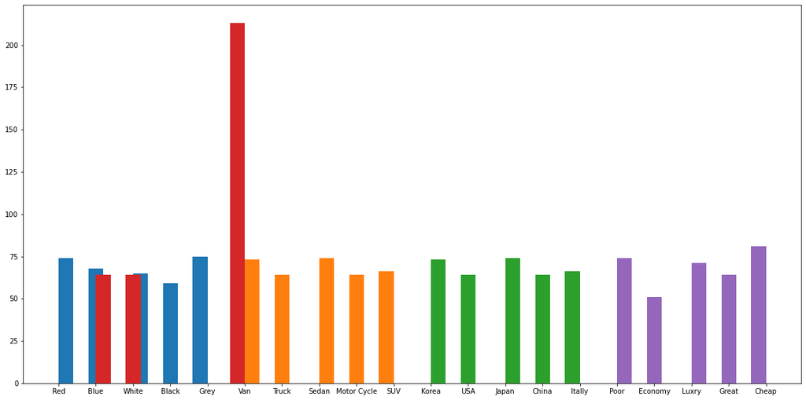

```python
plt.rcParams["figure.figsize"] = (20,10)
cols = df.columns
for col in cols:
    plt.hist(df[col])
```

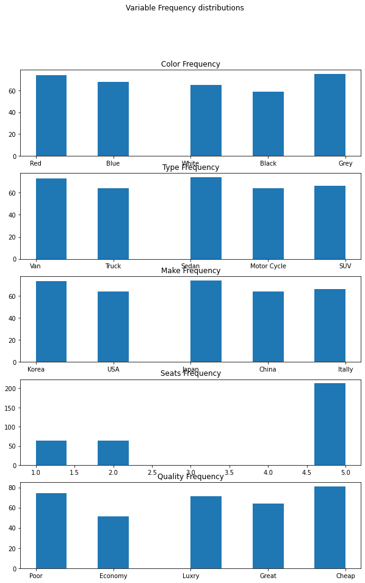

```python
plt.rcParams["figure.figsize"] = (10,15)
fig, axs = plt.subplots(5)
fig.suptitle('Variable Frequency distributions')
cols = df.columns
i=0
for col in cols:
    axs[i].hist(df[col])
    axs[i].set_title(col+' Frequency')
    i+=1
```

First, we will start with comparing color Vs. Type then we will create an algorithm that will display all possible combinations and the associated statistical measurements.

```python
from scipy.stats import chi2_contingency
```

```python
# define our alpha
alpha =.05

#Convert the raw data into a crosstab tabel (this will show the freqencies of paired categorical variable values)
contingency = pd.crosstab(df['Color'],df['Type'])
```

```python
contingency.head()
```

| Type Color | Motor Cycle | SUV | Sedan | Truck | Van |
| --- | --- | --- | --- | --- | --- |
| Black | 11 | 14 | 12 | 11 | 11 |
| Blue | 14 | 14 | 13 | 13 | 14 |
| Grey | 13 | 17 | 18 | 9 | 18 |
| Red | 14 | 12 | 20 | 15 | 13 |
| White | 12 | 9 | 11 | 16 | 17 |

Now we will run the Chi Squared test with a alpha of .05. We will call the Chi2_contingency function which will return

1. **Chi2** test statistic
2. **p value** whcih we will use to accept or reject our hypothesis the
3. **dof** or degrees of freedom and the
4. **expected** frequencies based on teh marginal sums of the tabel

```python
c, p, dof, expected = chi2_contingency(contingency)
p
```

```
0.8901314477364832
```

We can see our p value is greater than .05 so we fail to reject the null hypothesis, which is that the Variables are independent

Now let’s run the same test but for two variables we think may have an association and thus not be independent of each other for the next example we will use Vehicle type and number of seats

```python
contingency = pd.crosstab(df['Seats'],df['Type'])
contingency.head()
```

| Type Seats | Motor Cycle | SUV | Sedan | Truck | Van |
| --- | --- | --- | --- | --- | --- |
| 1 | 64 | 0 | 0 | 0 | 0 |
| 2 | 0 | 0 | 0 | 64 | 0 |
| 5 | 0 | 66 | 74 | 0 | 73 |

```python
c, p, dof, expected = chi2_contingency(contingency)
p
```

```
5.364384506803071e-142
```

this time we see a very small p-value much below our threshold of .05 which means that we reject the null hypothesis that these two variables are independent. And if you look at the contingency table this makes sense because for each column of Vehicle type there is only one Seat Value that has a number in it.

We will first contruct a Matrix that will hold the p-values for each possible relationsship

```python
headers=df.columns
chi_squared_matrix=pd.DataFrame(df,columns=headers,index=headers)
chi_squared_matrix.head()
```

|  | Color | Type | Make | Seats | Quality |
| --- | --- | --- | --- | --- | --- |
| Color | NaN | NaN | NaN | NaN | NaN |
| Type | NaN | NaN | NaN | NaN | NaN |
| Make | NaN | NaN | NaN | NaN | NaN |
| Seats | NaN | NaN | NaN | NaN | NaN |
| Quality | NaN | NaN | NaN | NaN | NaN |

Above is our chi matrix which. Each cell can be interpreted as the p-value for the corresponding row and column that it belongs to thus we will expect very low p-values along the diagonal as that is where we are comparing our variables against themselves

Now we will create a loop to insert the P-values into our dataframe which we can then print to see all the possible relationships between our 5 variables

```python
row=0
header=0
for col in headers: # Outer loop
    for index in headers: # inner loop
        # Convert the data into a contingency table
        contingency=pd.crosstab(df[col],df[index])
        #Run the chi-squared test
        c, p, dof, expected = chi2_contingency(contingency)
        # Rounding very small p-values to zero and insert it into the matrix
        chi_squared_matrix.iloc[row,header]=round(p,5)
        chi_squared_matrix.iloc[row,header].astype(float, copy=False)
        # Insert the P-value into the matrix
        header+=1
    row+=1
    header=0

chi_squared_matrix.head()
```

|  | Color | Type | Make | Seats | Quality |
| --- | --- | --- | --- | --- | --- |
| Color | 0.0 | 0.89013 | 0.89013 | 0.80673 | 0.50426 |
| Type | 0.89013 | 0.0 | 0.0 | 0.00000 | 0.23941 |
| Make | 0.89013 | 0.0 | 0.0 | 0.00000 | 0.23941 |
| Seats | 0.80673 | 0.0 | 0.0 | 0.00000 | 0.11875 |
| Quality | 0.50426 | 0.23941 | 0.23941 | 0.11875 | 0.0 |

To interpret the above p-value matrix we take the row index and column index then select the number(p-value) at their intersection to see if there is a possible relationship between the two variables. Some observations we can make based on the above results are

```
1. the Number of seats is not independent of the Car type or Make
2. the Car Make is not independent of the type i.e. some countries only produce certain car types
3. each variable is not independent of themselves thus the 0's across the diagonal
```

```python
chi_squared_matrix['Color']
```

```
Color          0.0
Type       0.89013
Make       0.89013
Seats      0.80673
Quality    0.50426
Name: Color, dtype: object
```

now lets vizualize this on a heatmap

```python
import seaborn as sns
```

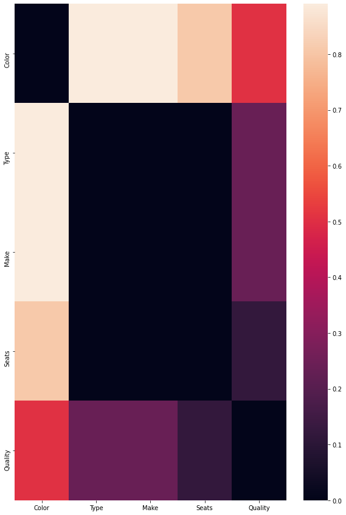

```python
sns.heatmap(chi_squared_matrix.astype(float))
```